# Comparison of COVID counts from USAFacts and New York Times - 7/13/20

There are several national-level aggregations of county-level COVID case and death data.

Each source has its own data collection methods, which can result in variations in numbers across sources.

On this page, we explore to what extent the following two data sources for county-level cumulative counts of confirmed COVID-19 cases and deaths are comparable. In our comparison, we focus on cumulative case counts as of 7/13/2020 (data accessed on 7/14/2020).

**New York Times (NYT)**: The New York times keeps maintains a [data set](https://github.com/nytimes/covid-19-data) reporting daily cumulative counts of COVID-19 cases and deaths.

**USAFacts**: USAFacts also maintains a [data set](https://usafacts.org/visualizations/coronavirus-covid-19-spread-map/) reporting daily cumulative counts of COVID-19 cases and deaths.

The data for each of the two sources are gathered from state and local public health agencies, however there are some differences between the two sources in how the data is reported. This [blog post](https://source.opennews.org/articles/comparison-four-major-covid-19-data-sources/) reviews some of the major differences, for example:

1. **Time of update:** NYT is updated once daily around 8am EDT with case and death counts from the previous day. USAFacts is updated once daily around 12am PDT (3am EDT) for cases from the previous day. Because USAFacts is updated before NYT, USAFacts generally reports lower case and death counts than NYT for a given day.
2. **Geographic exceptions:** NYT reports cases for all five boroughs of New York city as a single area (“New York City”). USAFacts reports New York City cases separately for all five counties, though also has a category for “New York City Unallocated/Probable”. NYT reports all case for Kansas City in a single group (“Kansas City”). The case counts for the four counties that include parts of Kansas City represent only the parts of the counties that are outside of Kansas City. In the USAFacts data, all Kansas City cases are allocated to Jackson County.
3. **Other differences:** See the blog post linked above for more information on the differences between the data sources.

## 1) Comparison of total national cases and deaths over time

### Cases

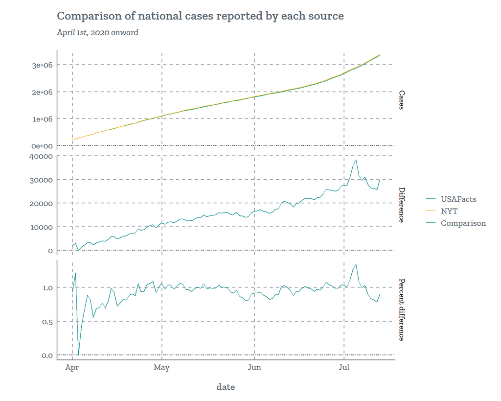

### Deaths

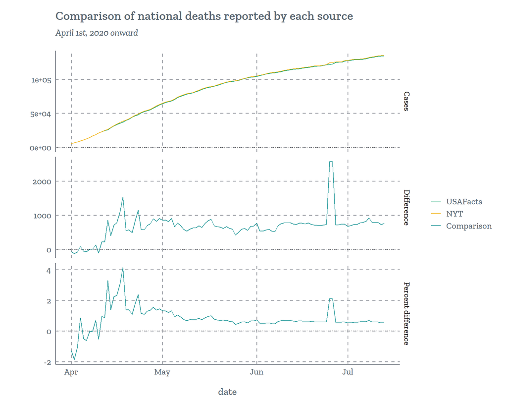

## 2) Comparison of unallocated cases

### Unallocated cases and deaths by state

This plot shows only states where there are unallocated cases or deaths in either data source.

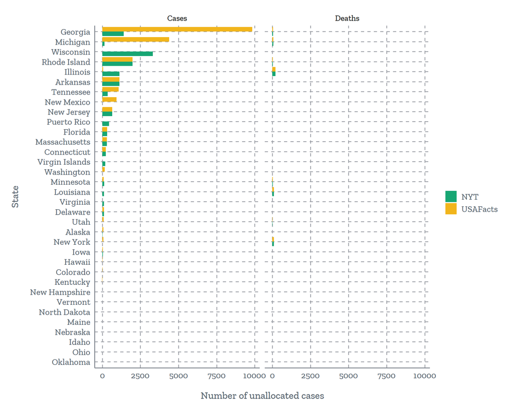

### Deaths categorized as New York City unallocated in USAFacts

There are currently only a handful of such deaths, and no such cases

| County | State | Cases | Deaths |
| --- | --- | --- | --- |
| New York City Unallocated/Probable | NY | 0 | 37 |

## 3) Comparison of counties with reported cases in the two data sets

We check for counties (FIPs codes) where cases were reported in one data set but not in the other.

All county FIPS codes from the New York Times data are in the USAFacts data with the exception of FIPS codes corresponding to counties in Puerto Rico.

| State | # counties in nyt but missing from usafacts |
| --- | --- |
| Puerto Rico | 78 |

There are a few FIPs codes that appear in the USAFacts data but not in the NYT:

| State | County | Fips | Cummulative cases | Earliest date | Latest date |
| --- | --- | --- | --- | --- | --- |
| CA | Grand Princess Cruise Ship | 06000 | 21 | 2020-03-07 | 2020-07-13 |
| NY | Bronx County | 36005 | 48377 | 2020-03-08 | 2020-07-13 |
| NY | Kings County | 36047 | 60815 | 2020-03-05 | 2020-07-13 |
| NY | New York County | 36061 | 29302 | 2020-03-02 | 2020-07-13 |
| NY | Queens County | 36081 | 66466 | 2020-03-07 | 2020-07-13 |
| NY | Richmond County | 36085 | 14341 | 2020-03-09 | 2020-07-13 |
| VA | Martinsville city | 51690 | 117 | 2020-04-28 | 2020-07-13 |

## 4) Comparison of cumulative cases for all counties that appear in both data sets

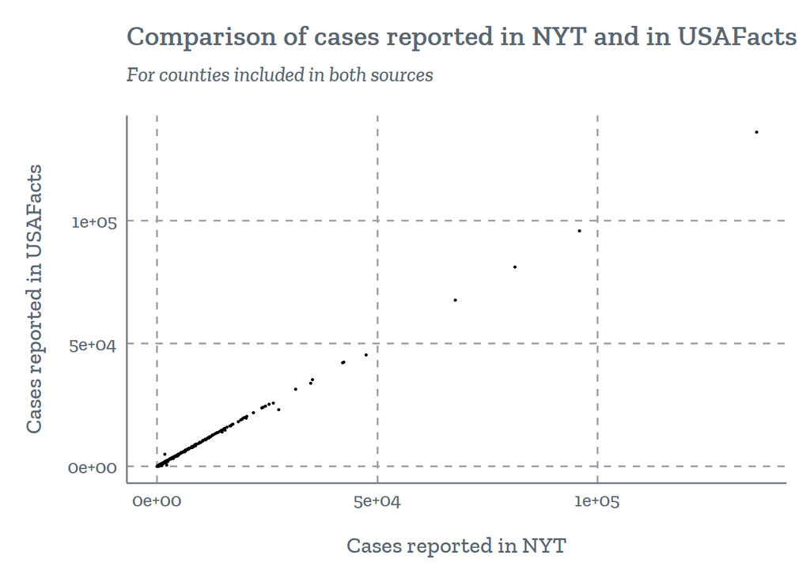

### Counties where the case count in USAFacts differs from the case count in NYT by more than 5%

#### Plot

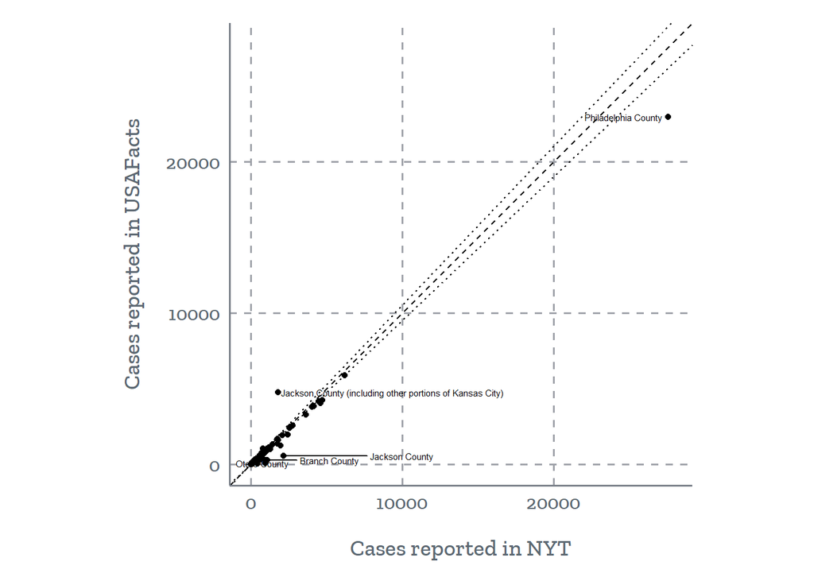

#### Table

The following table is arranged in descending order of the absolute value of the difference between the two sources.

| State | County usafacts | Fips | Nyt | Usafacts | Percent error |
| --- | --- | --- | --- | --- | --- |
| PA | Philadelphia County | 42101 | 27575 | 22987 | -17% |
| MO | Jackson County (including other portions of Kansas City) | 29095 | 1781 | 4767 | 168% |
| MI | Jackson County | 26075 | 2163 | 555 | -74% |
| NM | Otero County | 35035 | 950 | 79 | -92% |
| MI | Branch County | 26023 | 1062 | 269 | -75% |
| MI | Lenawee County | 26091 | 1013 | 283 | -72% |
| TX | Ector County | 48135 | 1964 | 1235 | -37% |
| WA | Snohomish County | 53061 | 4613 | 4033 | -13% |
| MI | Washtenaw County | 26161 | 2433 | 1938 | -20% |
| CA | Ventura County | 06111 | 4724 | 4246 | -10% |
| CA | Lassen County | 06035 | 428 | 35 | -92% |
| MO | St. Charles County | 29183 | 1760 | 1371 | -22% |
| WA | Pierce County | 53053 | 3634 | 3257 | -10% |
| TX | Galveston County | 48167 | 6201 | 5873 | -5% |
| ID | Ada County | 16001 | 4472 | 4146 | -7% |
| TX | Cameron County | 48061 | 4175 | 3854 | -8% |
| MI | Lapeer County | 26087 | 632 | 325 | -49% |
| TX | Comal County | 48091 | 1282 | 977 | -24% |
| IN | Shelby County | 18145 | 701 | 460 | -34% |
| MO | Jasper County | 29097 | 778 | 1019 | 31% |
| TX | Williamson County | 48491 | 4042 | 3810 | -6% |
| TX | Val Verde County | 48465 | 699 | 503 | -28% |
| TX | Victoria County | 48469 | 1795 | 1599 | -11% |
| IN | Wayne County | 18177 | 354 | 159 | -55% |
| WA | Clark County | 53011 | 1272 | 1078 | -15% |
| TX | McLennan County | 48309 | 2744 | 2557 | -7% |
| MO | Jefferson County | 29099 | 769 | 594 | -23% |
| MO | McDonald County | 29119 | 887 | 712 | -20% |
| WA | Benton County | 53005 | 2557 | 2387 | -7% |
| MO | Boone County | 29019 | 764 | 595 | -22% |

[output cut: 161 more lines]

## 5) Comparison of cumulative deaths for all counties that appear in both data sets

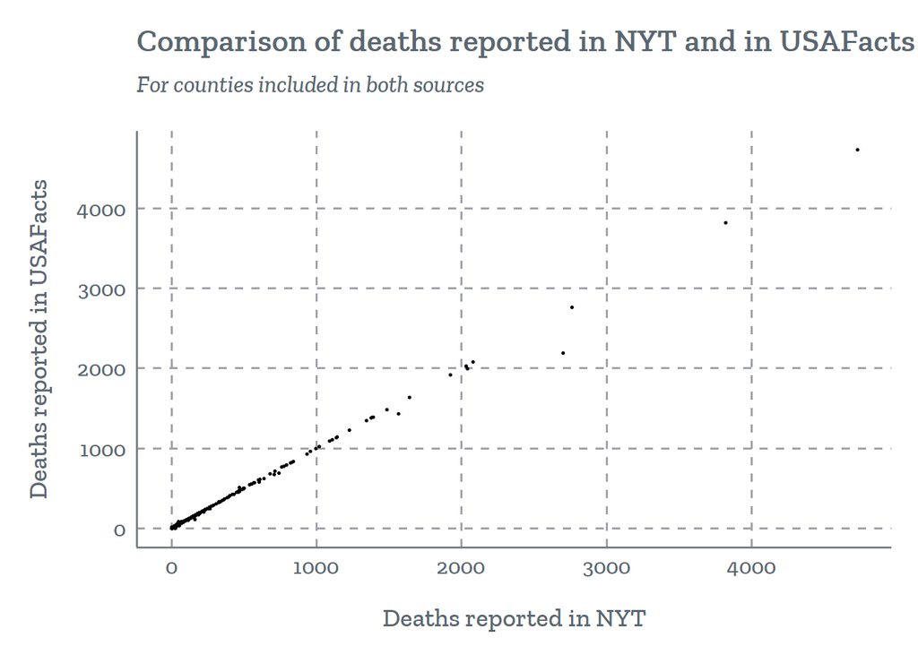

### Counties where the death count in USAFacts differs from the death count in NYT by more than 5%

#### Plot

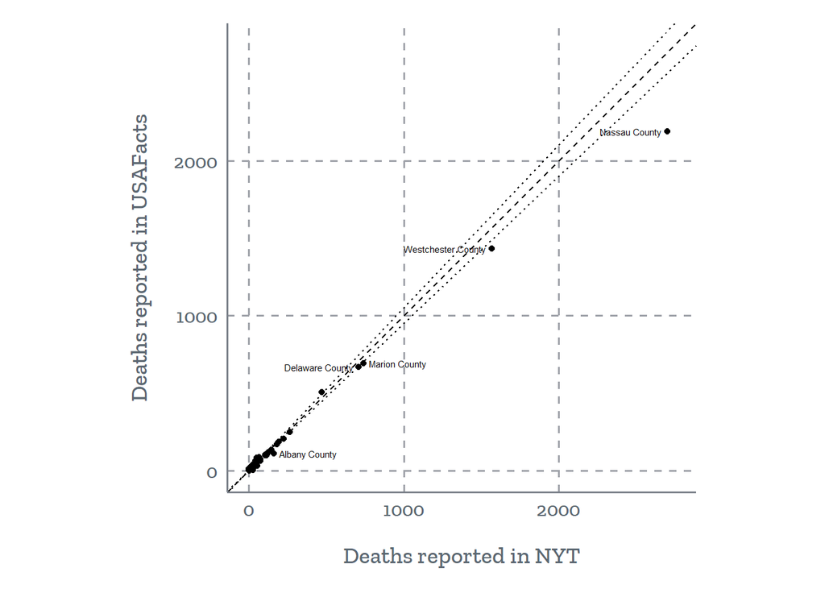

#### Table

The following table is arranged in descending order of the absolute value of the difference between the two sources.

| State | County usafacts | Fips | Nyt | Usafacts | Percent error |
| --- | --- | --- | --- | --- | --- |
| NY | Nassau County | 36059 | 2701 | 2190 | -19% |
| NY | Westchester County | 36119 | 1567 | 1435 | -8% |
| NY | Albany County | 36001 | 161 | 109 | -32% |
| IN | Marion County | 18097 | 739 | 693 | -6% |
| PA | Delaware County | 42045 | 709 | 668 | -6% |
| NY | Rockland County | 36087 | 469 | 506 | 8% |
| NY | Ulster County | 36111 | 49 | 81 | 65% |
| MI | Branch County | 26023 | 25 | 2 | -92% |
| MI | Jackson County | 26075 | 54 | 32 | -41% |
| NY | Niagara County | 36063 | 67 | 85 | 27% |
| KY | Jefferson County | 21111 | 224 | 206 | -8% |
| MO | Jackson County (including other portions of Kansas City) | 29095 | 44 | 61 | 39% |
| IN | Hendricks County | 18063 | 116 | 100 | -14% |
| NY | Monroe County | 36055 | 264 | 248 | -6% |
| IN | Lake County | 18089 | 265 | 249 | -6% |
| NY | Orleans County | 36073 | 41 | 55 | 34% |
| NY | Onondaga County | 36067 | 183 | 169 | -8% |
| TX | Bowie County | 48037 | 28 | 16 | -43% |
| TX | Bexar County | 48029 | 195 | 184 | -6% |
| MO | Jasper County | 29097 | 1 | 11 | 1000% |
| NY | Saratoga County | 36091 | 5 | 15 | 200% |
| NY | Steuben County | 36101 | 19 | 29 | 53% |
| CA | Marin County | 06041 | 28 | 38 | 36% |
| NC | Buncombe County | 37021 | 41 | 31 | -24% |
| IN | Madison County | 18095 | 74 | 64 | -14% |
| MI | Washtenaw County | 26161 | 118 | 108 | -8% |
| IN | Allen County | 18003 | 144 | 134 | -7% |
| WA | Yakima County | 53077 | 190 | 180 | -5% |
| NY | Greene County | 36039 | 5 | 13 | 160% |
| NY | Fulton County | 36035 | 18 | 26 | 44% |

[output cut: 105 more lines]